# Judgement ⑨ — side-effect extraction: do models agree on the AE set?

For each (post, drug) the classifier extracts a **set of side-effects**. This is a fully-wired field that already feeds the FDA tolerability analysis, so its reliability matters — but it has no external gold, so the only honest question is *agreement*: given the same post and drug, do models extract the same adverse events? Measured across the roster on the IRR labelled pairs, metric = mean pairwise Jaccard on the AE sets.

*(loaded — 2379 classifications, 22 models; overall mean pairwise AE-set agreement 85%; 77% of extractions report no side-effects)*

## 1. How much do models agree on the side-effect set?

Mean pairwise Jaccard on the AE sets, per model against the rest.

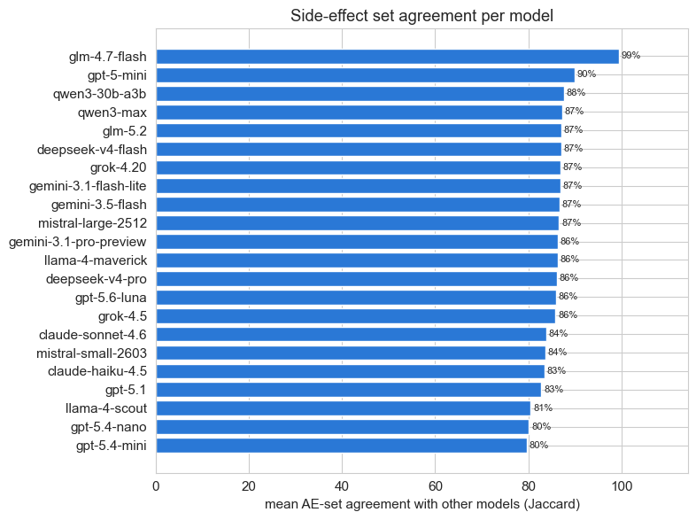

**Agreement is low (85% overall)** — but AE sets are small and sparse, so Jaccard is punishing (one model lists `insomnia`, another `sleep problems`, a third nothing → near-zero overlap). Two structural reasons agreement is genuinely hard here: (a) side-effects are only mentioned in passing in most posts, so presence is noisy; (b) free-text AE strings aren't normalized. **The takeaway isn't a clean number — it's that raw side-effect *sets* are the least reliable field, and any AE analysis needs string normalization + a presence threshold before trusting cross-model or cross-community counts.**

## 2. What gets reported — and the sparsity problem

**Most-extracted side-effects (raw strings, unnormalised)**

| side-effect (verbatim) | times extracted |
| --- | --- |
| weight gain | 63 |
| anxiety | 41 |
| fatigue | 31 |
| aggravated some unrelated stuff | 25 |
| decreased libido | 23 |
| headaches | 22 |
| feeling like shit | 20 |
| slower cognitive function | 20 |
| body aches | 19 |
| feel like shit | 18 |
| hyperalgesia | 18 |
| drowsiness | 18 |
| swimmy head | 17 |
| chest tight | 17 |
| itchy | 17 |

**77% of extractions report NO side-effect at all** — most posts don't discuss AEs for the drug in question, so the field is mostly empty and the non-empty entries are a thin, noisy signal. The raw strings above also show the normalisation gap (synonyms/spellings uncollapsed), which is exactly what drags the Jaccard agreement down and what an ontology pass (MedDRA/UMLS) would fix.

## 3. The two threats that matter for the FDA use

Side-effects feed the FDA tolerability work (`FDA_analysis/build_ldn_ae.py`, `ldn_two_community_tolerability.ipynb`), so two known threats are load-bearing:

- **LIST-FANOUT** (`intervention_config.py:164`) — the prompt pins a reported symptom to *every* drug named in a stacked post. So on multi-treatment posts, each drug inherits the whole post's AE list, inflating per-drug side-effect counts exactly as the group-attribution rule inflates per-drug *positives* (judgement ⑤). Any per-drug AE profile from stacked posts is suspect.
- **DR4 (verbosity confound)** — the FDA work compares AE profiles *across communities* (CLH vs Phoenix). If one community writes longer posts, its AE lists look richer and the comparison measures verbosity, not tolerability. **Run DR4's flatness check (AE-set size vs post length, per community) before trusting any cross-community AE comparison.**

Both mean: the side-effect field is usable for *within-post presence* signals, but per-drug and cross-community AE *counts* need the fan-out correction and the verbosity check first.

## 4. Verdict

- **Side-effect sets are the least-reliable field** — ~85% mean pairwise agreement, and ~77% of extractions are empty. Partly Jaccard punishing sparse sets, partly genuine presence noise + unnormalised strings.

- **Not a clean pass/fail** — with no gold, this is agreement-only, and the low number is as much a metric and sparsity artifact as a model failure (same lesson as the variable-coding N×N). A MedDRA/UMLS normalization pass + a presence threshold would lift the usable signal substantially.

- **Two corrections are mandatory before the FDA AE use:** the LIST-FANOUT fan-out (per-drug counts on stacked posts) and the DR4 verbosity check (cross-community counts). Neither is optional given how AE profiles are compared downstream.

- **Recommendation:** treat raw AE sets as a *presence* signal only; normalize to an ontology and apply the two corrections before any per-drug or cross-community tolerability claim.

## Limitations

- **No gold** — agreement-only; models agreeing on an AE could share a prompt bias, and a low number is partly the sparse-set Jaccard artifact, not proven unreliability.
- **Jaccard on tiny sets is high-variance** — one differing term swings a pair from 1.0 to 0.0; absolute levels understate semantic agreement (`insomnia` vs `sleep problems`).
- **IRR labelled pairs only** (116 post×drug), K=1 — no within-model variability here; the across-model number is the primary readout.
- Describes agreement of a measurement step, not real adverse-event rates. Not medical advice.

**Provenance**

| item | value |
| --- | --- |
| field | side_effects (classify_batch) |
| models | 22 |
| pairs | 116 |
| metric | mean pairwise Jaccard on AE sets |
| threats | LIST-FANOUT + DR4 verbosity |
| skill | research-assistant v2 |

Describes agreement of a measurement step, not real adverse-event rates. Not medical advice.